# Comparing arima, ets and OLS with and without hierarchy process - Australian Domestic Tourism

August 15, 2018

## Six methods:

1. Forecasting hierarchical time series using **optimal combination reconciliation** with **arima** bottom level forecast
2. Forecasting hierarchical time series using **optimal combination reconciliation** with **ets** bottom level forecast
3. Forecasting hierarchical time series using **optimal combination reconciliation** with **OLS** bottom level forecast
4. Forecasting time series using **arima** models
5. Forecasting time series using **ets** models
6. Forecasting time series using **OLS** models

## TourismData: Comparing all methods - with and without hierarchy - mean(log(RMSE))

| Method | Mean(log(RMSE)) |
| --- | --- |
| arima | 1.58 |
| Hierarchy-arima | 1.705 |
| ets | 1.594 |
| Hierarchy-ets | 1.632 |
| OLS | 1.419 |
| Hierarchy-OLS | 1.737 |

## TourismData: Comparing three hierarchy methods - log(RMSE) Density plot

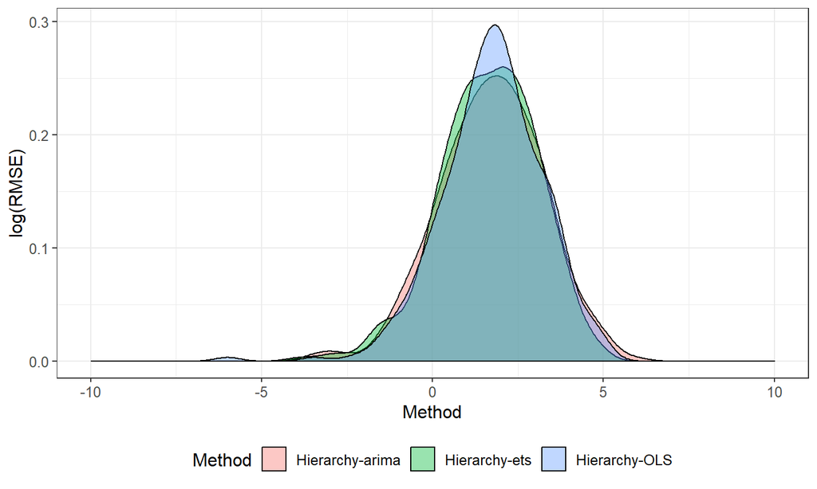

## TourismData: Comparing three hierarchy methods - log(RMSE) Boxplot

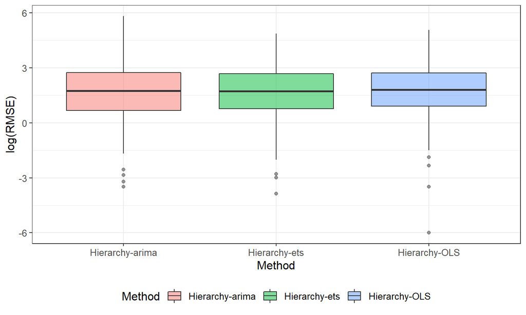

## TourismData: Comparing three hierarchy methods - Subtracted log(RMSE) Boxplot

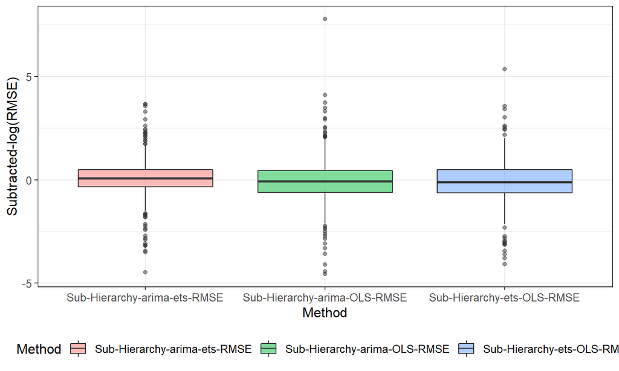

## TourismData: Comparing three hierarchy methods - Error Density plot

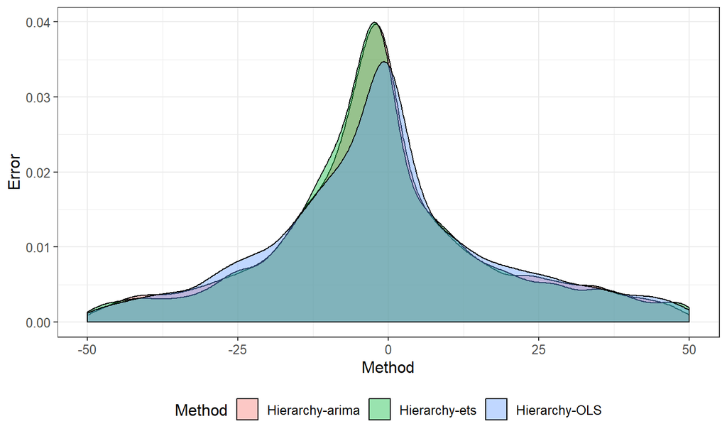

## TourismData: Comparing three hierarchy methods - Error Boxplot

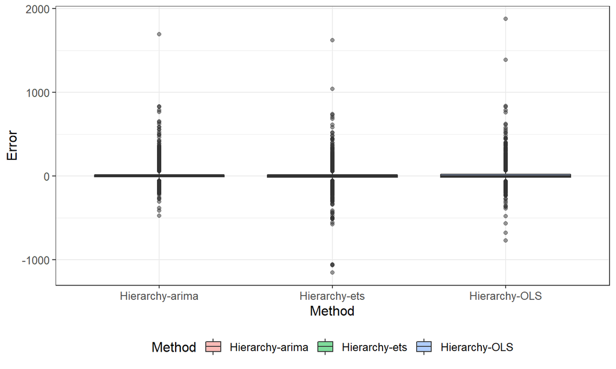

## TourismData: Comparing three hierarchy methods - Subtracted Error Boxplot

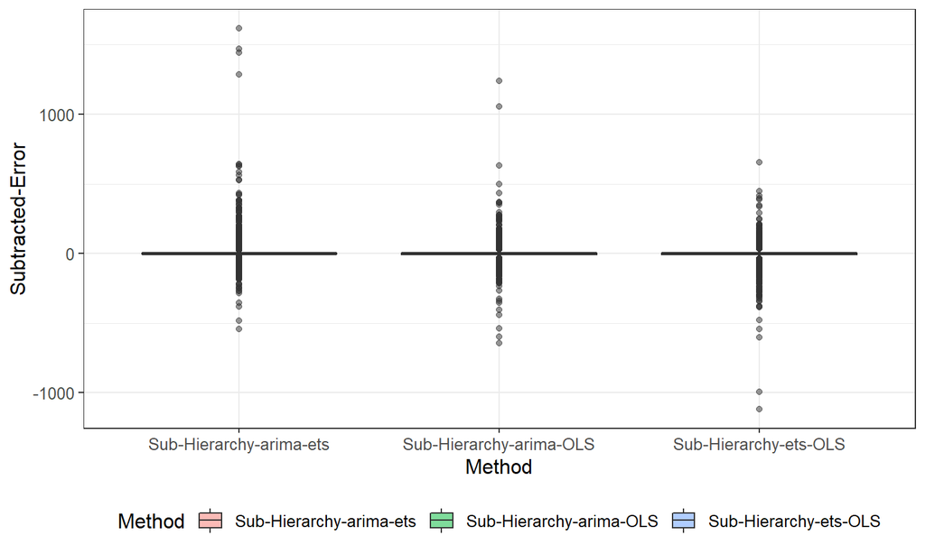

## TourismData: Comparing three hierarchy methods - Forecasted Series Plot

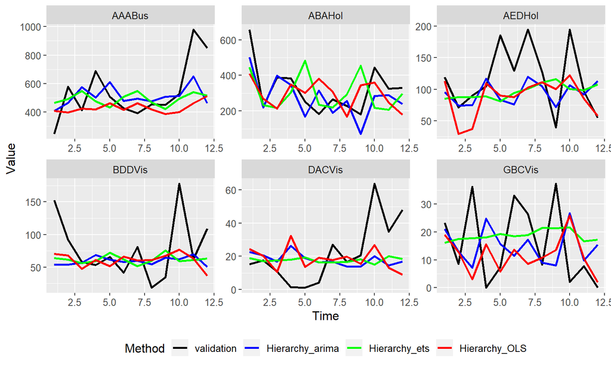

## TourismData: Comparing three methods - without hierarchy - log(RMSE) Density plot

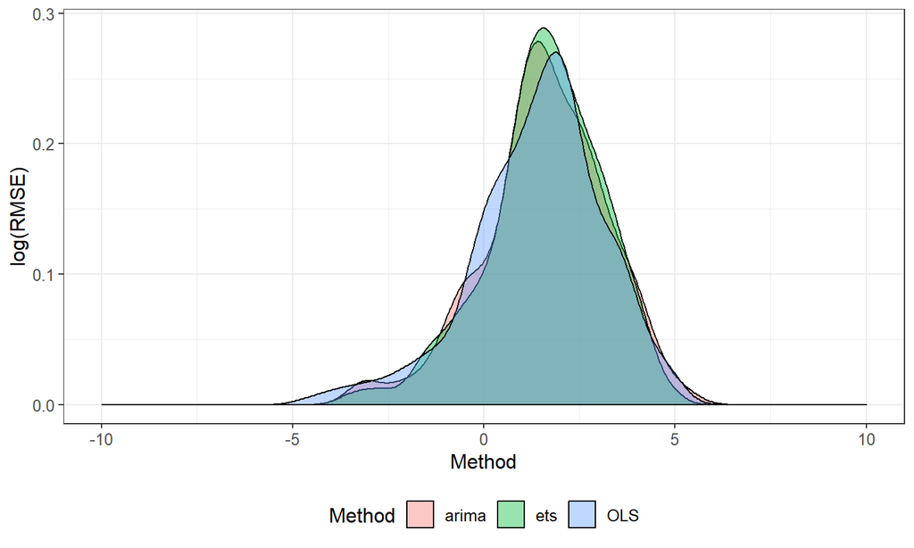

## TourismData: Comparing three methods - without hierarchy - log(RMSE) Boxplot

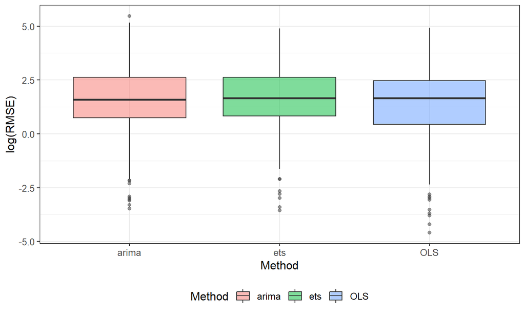

## TourismData: Comparing three methods - without hierarchy - Subtracted log(RMSE) Boxplot

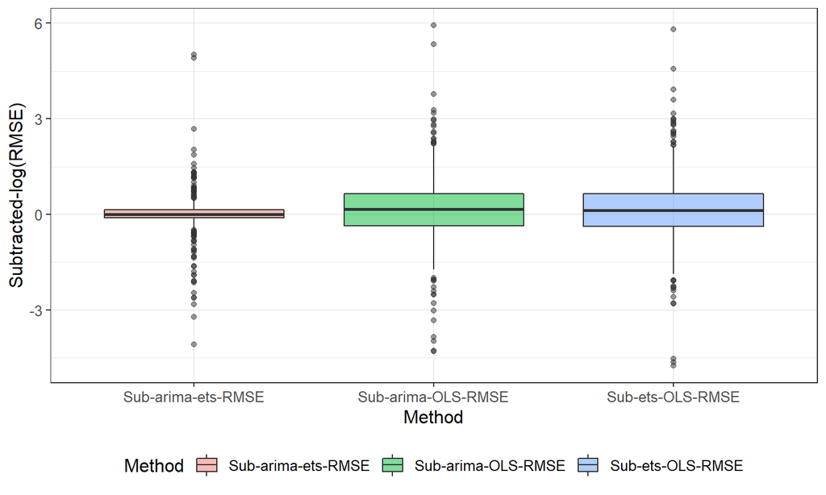

## TourismData: Comparing three methods - without hierarchy - Error Density plot

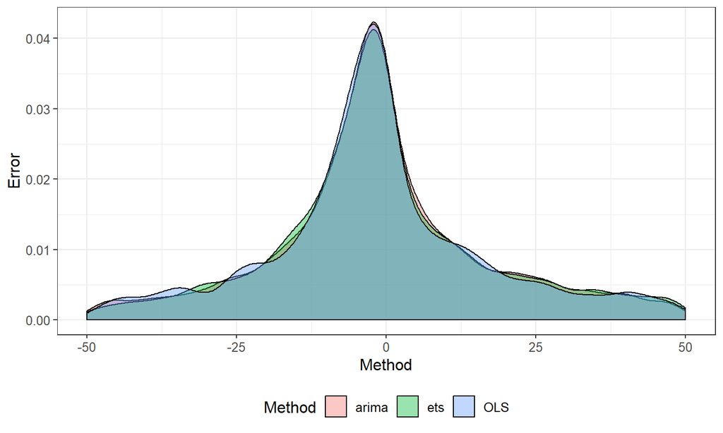

## TourismData: Comparing three methods - without hierarchy - Error Boxplot

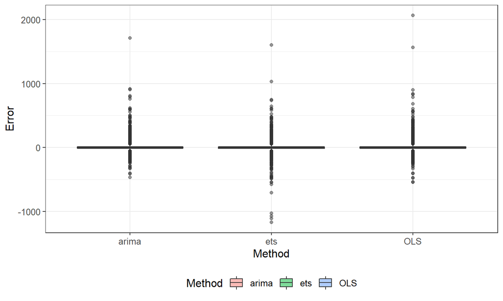

## TourismData: Comparing three methods - without hierarchy- Subtracted Error Boxplot

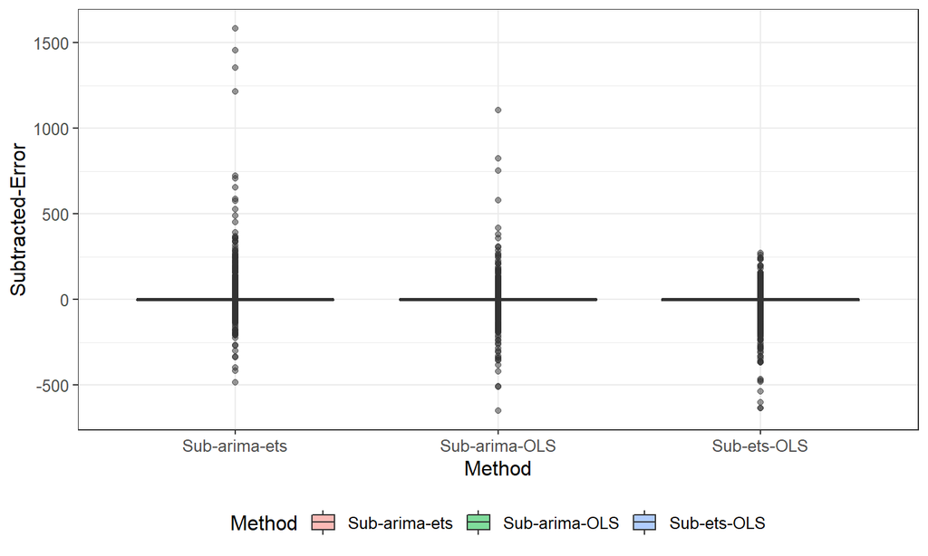

## TourismData: Comparing three methods - without hierarchy - Forecasted Series Plot

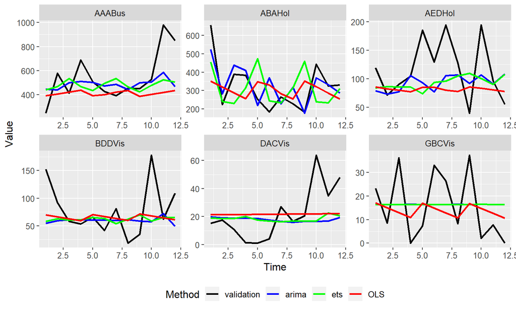

## TourismData: Comparing arima methods - with and without hierarchy - log(RMSE) Density plot

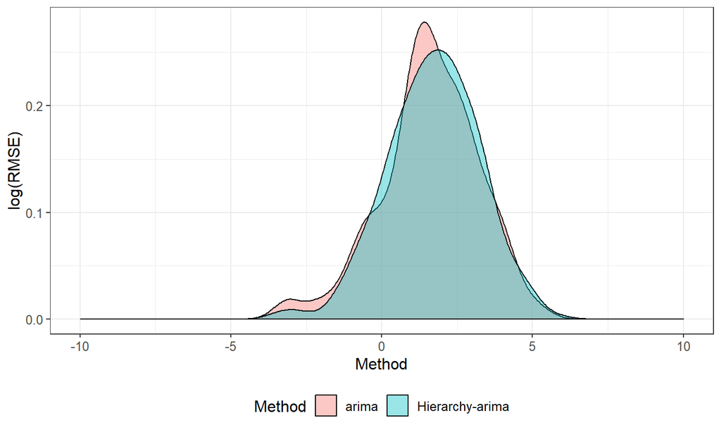

## TourismData: Comparing arima methods - with and without hierarchy - log(RMSE) Boxplot

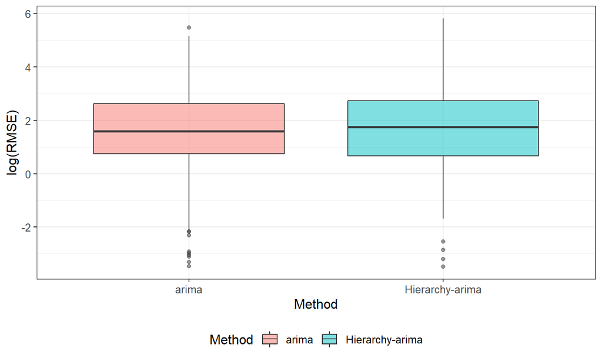

## TourismData: Comparing arima methods - with and without hierarchy - Subtracted log(RMSE) Boxplot

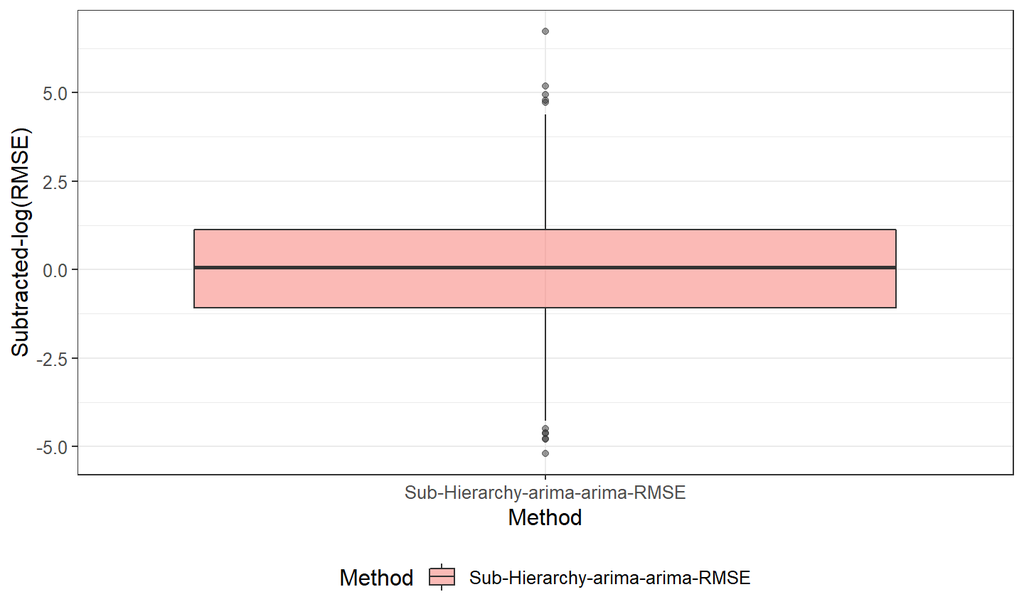

## TourismData: Comparing arima methods - with and without hierarchy - Error Density plot

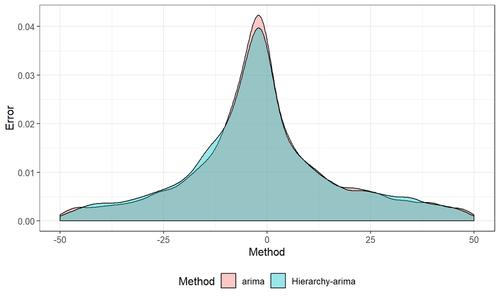

## TourismData: Comparing arima methods - with and without hierarchy - Error Boxplot

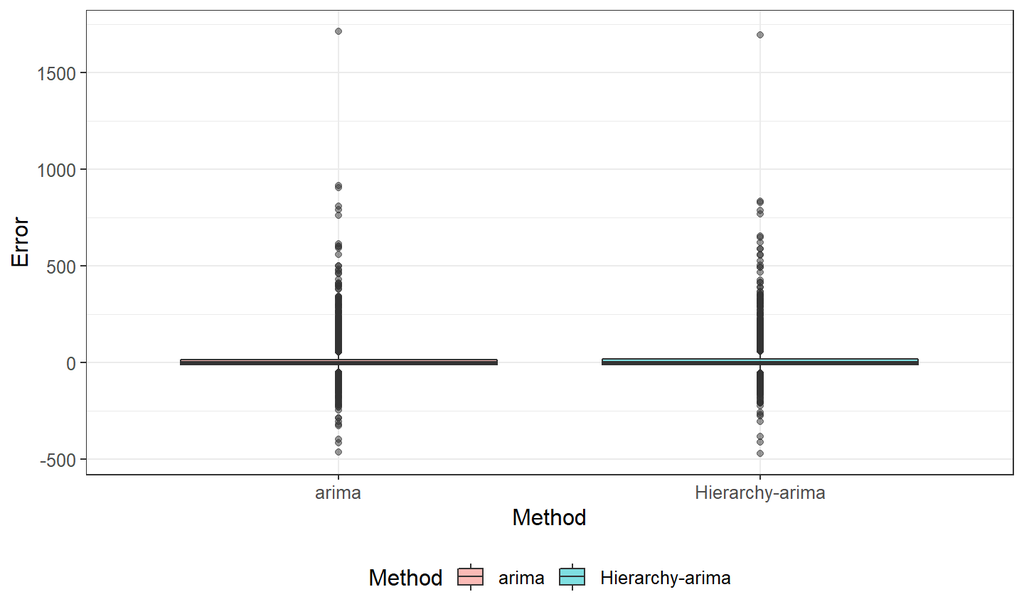

## TourismData: Comparing arima methods - with and without hierarchy - Subtracted Error Boxplot

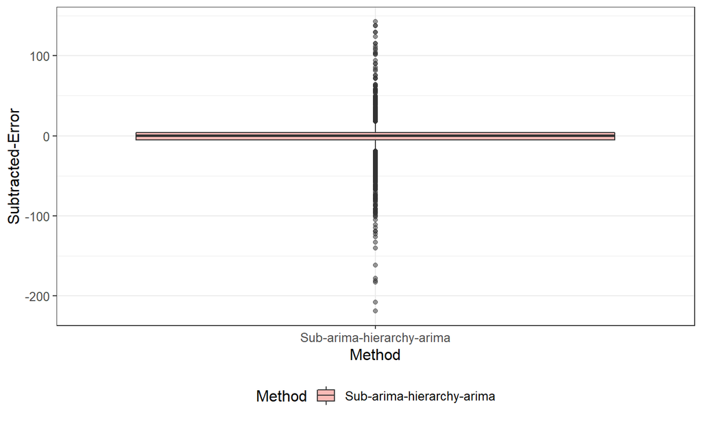

## TourismData: Comparing arima methods - with and without hierarchy - Forecasted Series Plot

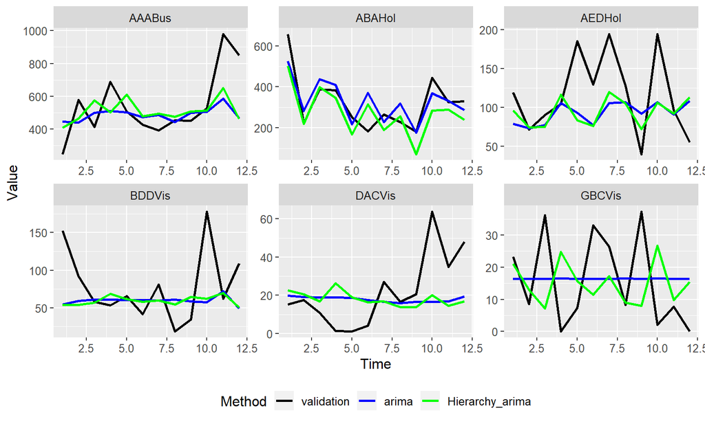

## TourismData: Comparing ets methods - with and without hierarchy - log(RMSE) Density plot

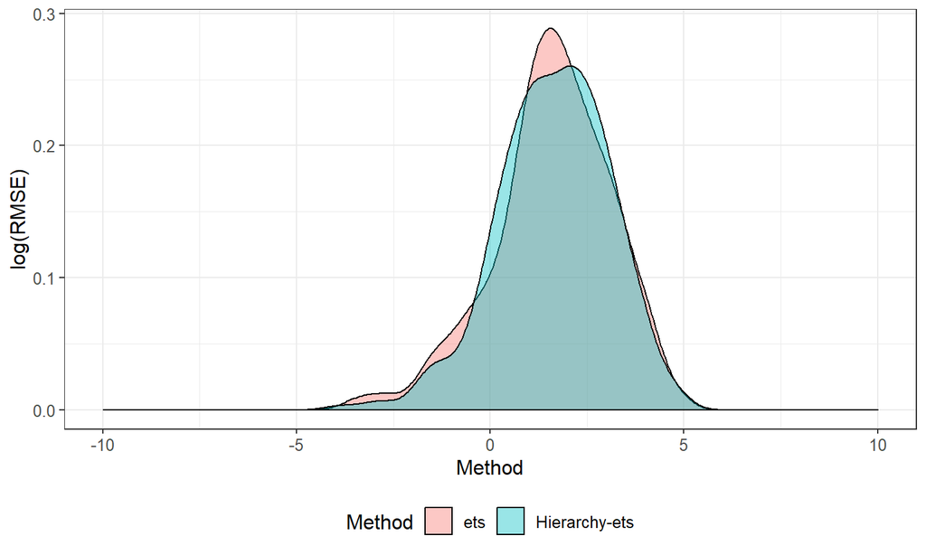

## TourismData: Comparing ets methods - with and without hierarchy - log(RMSE) Boxplot

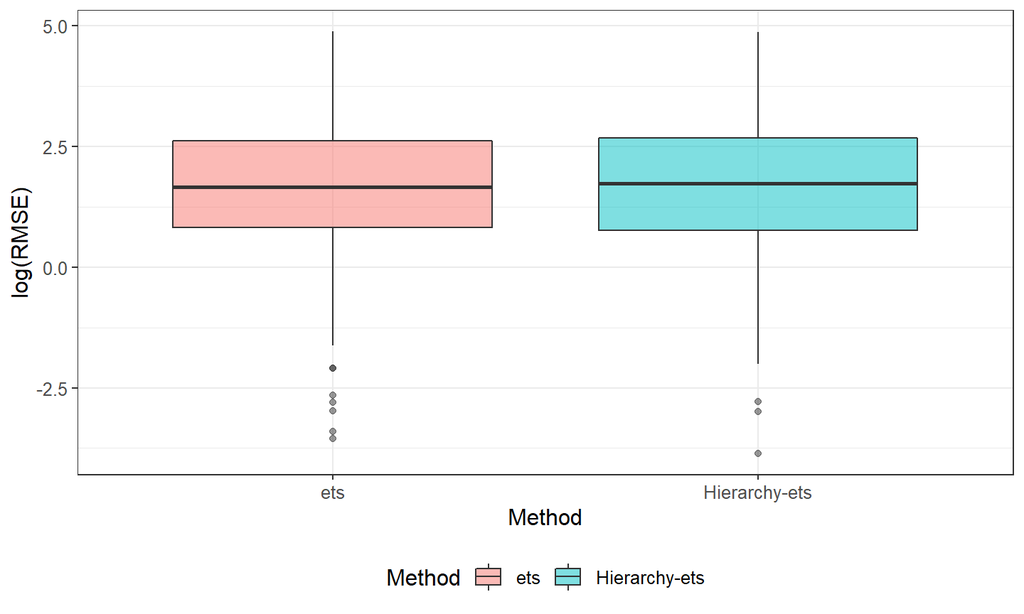

## TourismData: Comparing ets methods - with and without hierarchy - Subtracted log(RMSE) Boxplot

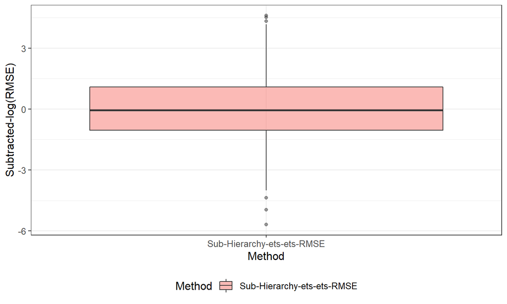

## TourismData: Comparing ets methods - with and without hierarchy - Error Density plot

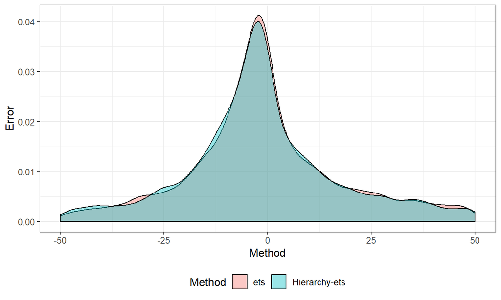

## TourismData: Comparing ets methods - with and without hierarchy - Error Boxplot

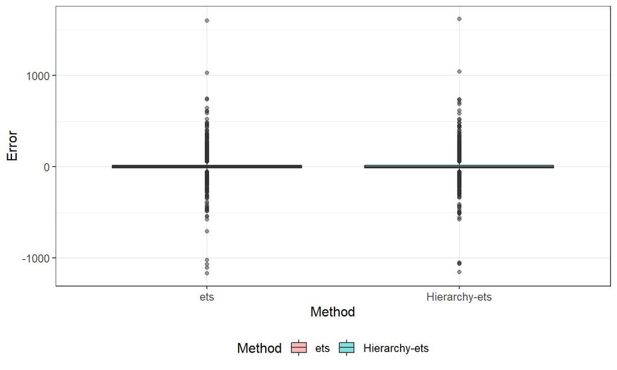

## TourismData: Comparing ets methods - with and without hierarchy - Subtracted Error Boxplot

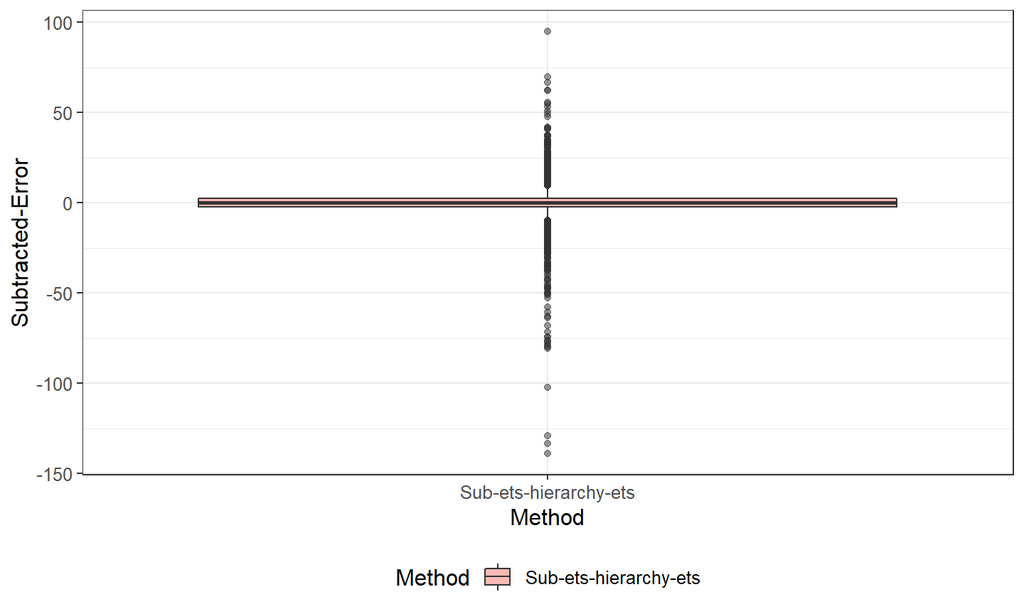

## TourismData: Comparing ets methods - with and without hierarchy - Forecasted Series Plot

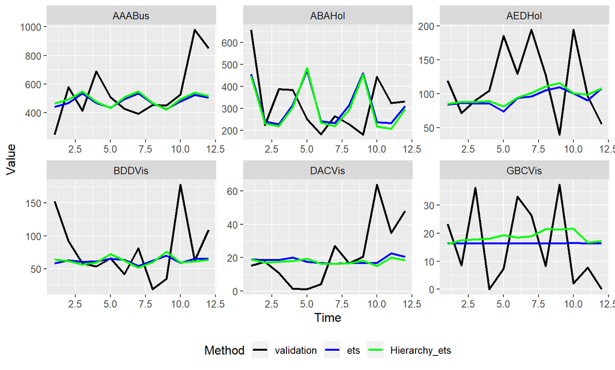

## Comparing OLS methods - with and without hierarchy - log(RMSE) Density plot

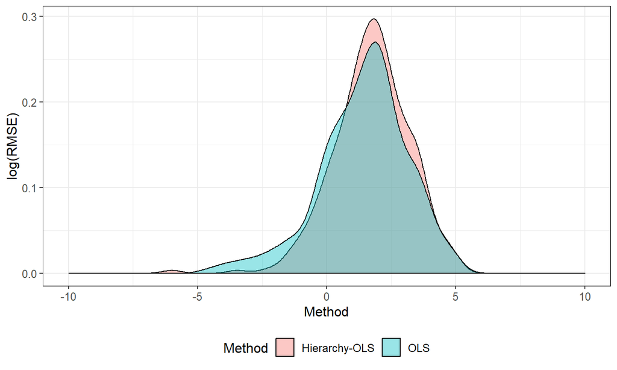

## TourismData: Comparing OLS methods - with and without hierarchy - log(RMSE) Boxplot

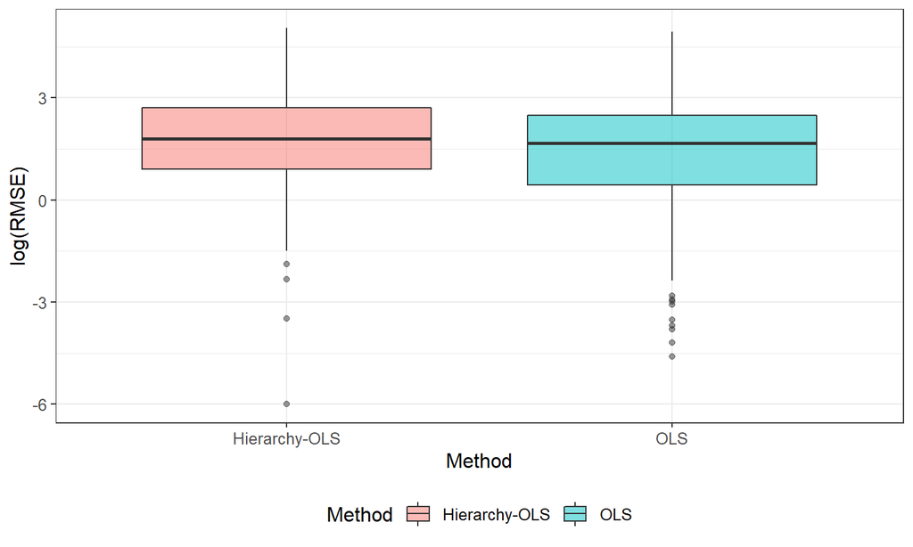

## TourismData: Comparing OLS methods - with and without hierarchy - Subtracted log(RMSE) Boxplot

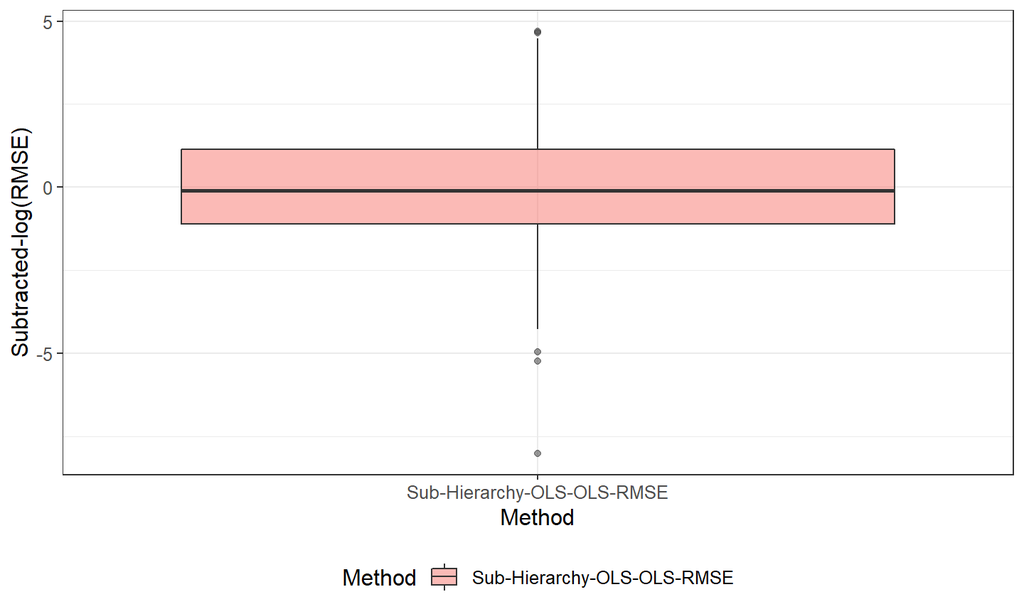

## TourismData: Comparing OLS methods - with and without hierarchy - Error Density plot

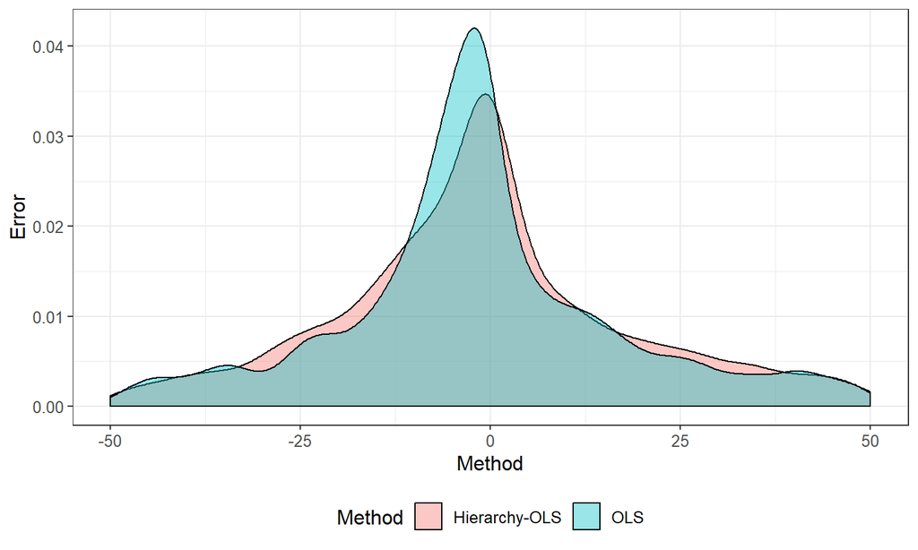

## TourismData: Comparing OLS methods - with and without hierarchy - Error Boxplot

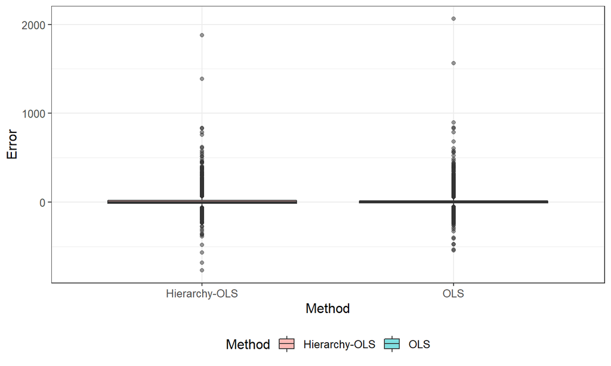

## TourismData: Comparing OLS methods - with and without hierarchy - Subtracted Error Boxplot

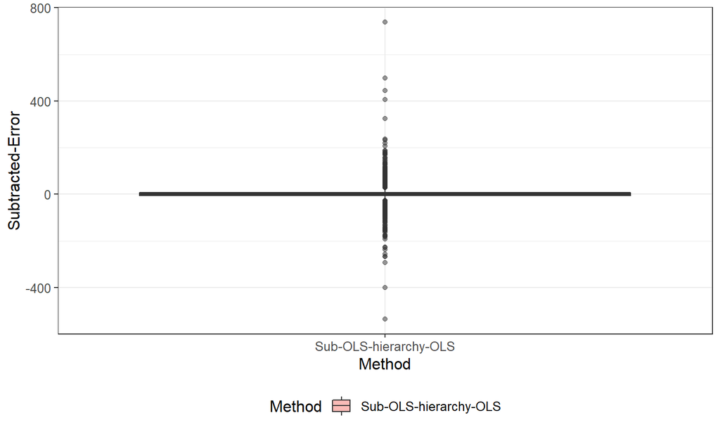

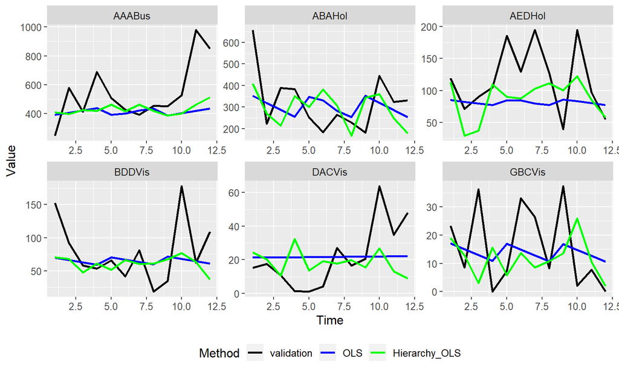

## TourismData: Comparing all methods - with and without hierarchy - log(RMSE) Density plot

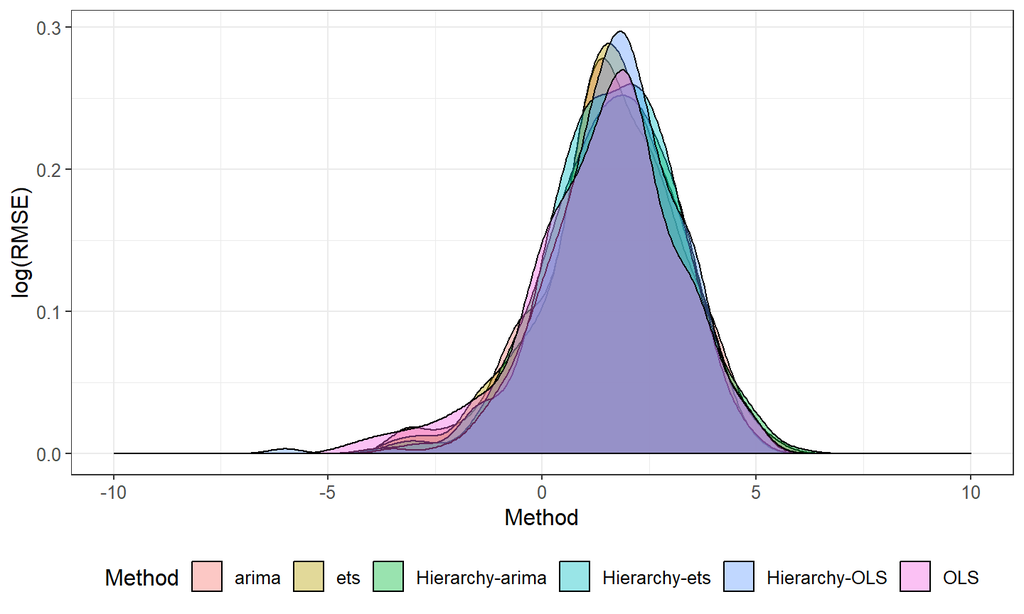

## TourismData: Comparing all methods - with and without hierarchy - log(RMSE) Boxplot

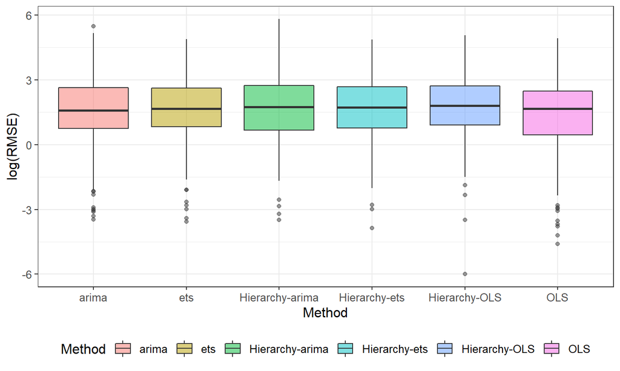

## TourismData: Comparing all methods - with and without hierarchy - Error Density plot

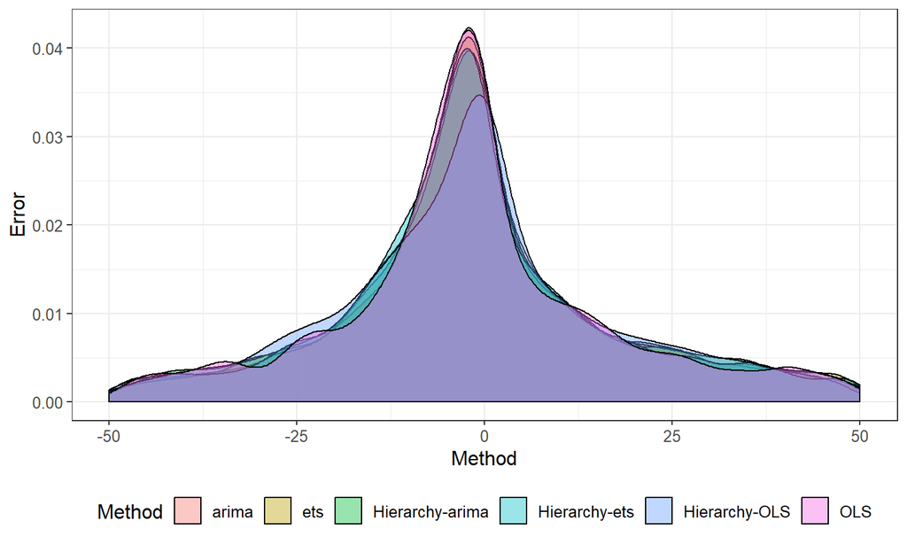

## TourismData: Comparing all methods - with and without hierarchy - Error Boxplot

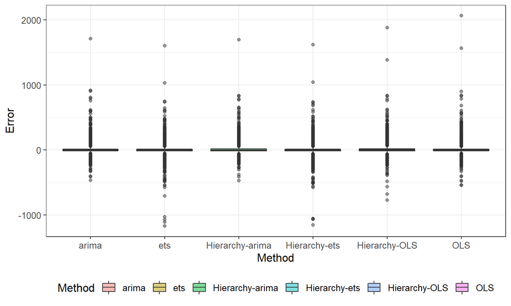

## TourismData: Comparing all methods - with and without hierarchy - Forecasted Series Plot

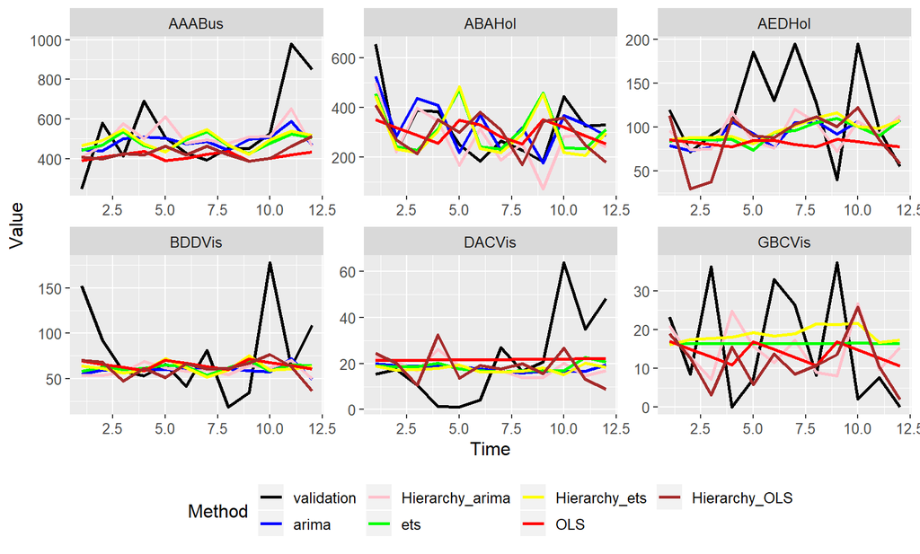